# W3cubDocs

/Kotlin

# Configure compilations

Kotlin multiplatform projects use compilations for producing artifacts. Each target can have one or more compilations, for example, for production and test purposes.

For each target, default compilations include:

- `main` and `test` compilations for JVM, JS, and Native targets.
- A compilation per [Android build variant](https://developer.android.com/studio/build/build-variants), for Android targets.

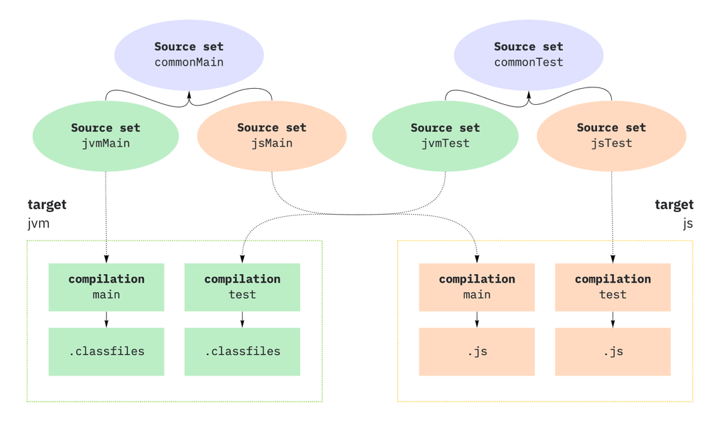

If you need to compile something other than production code and unit tests, for example, integration or performance tests, you can create a custom compilation.

You can configure how artifacts are produced in:

- All compilations in your project at once.
- Compilations for one target since one target can have multiple compilations.
- A specific compilation.

See the list of compilation parameters and compiler options available for all or specific targets.

## Configure all compilations

```
kotlin {
    targets.all {
        compilations.all {
            kotlinOptions {
                allWarningsAsErrors = true
            }
        }
    }
}
```

## Configure compilations for one target

```
kotlin {
    jvm().compilations.all {
        kotlinOptions {
            sourceMap = true
            metaInfo = true
        }
    }
}
```

```
kotlin {
    targets.jvm.compilations.all {
        kotlinOptions {
            sourceMap = true
            metaInfo = true
        }
    }
}
```

## Configure one compilation

```
kotlin {
    jvm().compilations.main {
        kotlinOptions {
            jvmTarget = "1.8"
        }
    }
}
```

```
kotlin {
    jvm {
        val main by compilations.getting {
            kotlinOptions {
                jvmTarget = "1.8"
            }
        }
    }
}
```

## Create a custom compilation

If you need to compile something other than production code and unit tests, for example, integration or performance tests, create a custom compilation.

For example, to create a custom compilation for integration tests of the `jvm()` target, add a new item to the `compilations` collection.

> For custom compilations, you need to set up all dependencies manually. The default source set of a custom compilation does not depend on the `commonMain` and the `commonTest` source sets.

```
kotlin {
    jvm() {
        compilations.create('integrationTest') {
            defaultSourceSet {
                dependencies {
                    def main = compilations.main
                            // Compile against the main compilation's compile classpath and outputs:
                            implementation(main.compileDependencyFiles + main.output.classesDirs)
                    implementation kotlin('test-junit')
                    /* ... */
                }
            }

            // Create a test task to run the tests produced by this compilation:
            tasks.create('jvmIntegrationTest', Test) {
                // Run the tests with the classpath containing the compile dependencies (including 'main'),
                // runtime dependencies, and the outputs of this compilation:
                classpath = compileDependencyFiles + runtimeDependencyFiles + output.allOutputs

                // Run only the tests from this compilation's outputs:
                testClassesDirs = output.classesDirs
            }
        }
    }
}
```

```
kotlin {
    jvm() {
        compilations {
            val main by getting

            val integrationTest by compilations.creating {
                defaultSourceSet {
                    dependencies {
                        // Compile against the main compilation's compile classpath and outputs:
                        implementation(main.compileDependencyFiles + main.output.classesDirs)
                        implementation(kotlin("test-junit"))
                        /* ... */
                    }
                }

                // Create a test task to run the tests produced by this compilation:
                tasks.create<Test>("integrationTest") {
                    // Run the tests with the classpath containing the compile dependencies (including 'main'),
                    // runtime dependencies, and the outputs of this compilation:
                    classpath = compileDependencyFiles + runtimeDependencyFiles + output.allOutputs

                    // Run only the tests from this compilation's outputs:
                    testClassesDirs = output.classesDirs
                }
            }
        }
    }
}
```

You also need to create a custom compilation in other cases, for example, if you want to combine compilations for different JVM versions in your final artifact, or you have already set up source sets in Gradle and want to migrate to a multiplatform project.

## Include Java sources in JVM compilations

By default, the JVM target ignores Java sources and compiles only Kotlin source files.

To include Java sources in the compilations of the JVM target, explicitly enable the Java language support for the target:

- When creating a project with the Project Wizard.

[figure not shown]

- In the build script of an existing project.

  ```
  kotlin {
      jvm {
          withJava()
      }
  }
  ```

  This applies the Gradle `java` plugin and configures the target to cooperate with it.

The Java source files are placed in the child directories of the Kotlin source roots. For example, the paths are:

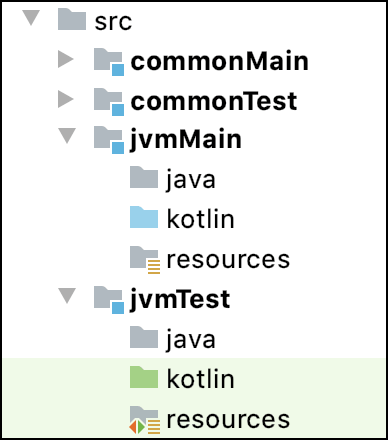

The common source sets cannot include Java sources.

Due to current limitations, the Kotlin plugin replaces some tasks configured by the Java plugin:

- The target's JAR task instead of `jar` (for example, `jvmJar`).
- The target's test task instead of `test` (for example, `jvmTest`).
- The resources are processed by the equivalent tasks of the compilations instead of `*ProcessResources` tasks.

The publication of this target is handled by the Kotlin plugin and doesn't require steps that are specific for the Java plugin.

## Configure interop with native languages

Kotlin provides interoperability with native languages and DSL to configure this for a specific compilation.

| Native language | Supported platforms | Comments |
| --- | --- | --- |
| C | All platforms, except for WebAssembly |  |
| Objective-C | Apple platforms (macOS, iOS, watchOS, tvOS) |  |
| Swift via Objective-C | Apple platforms (macOS, iOS, watchOS, tvOS) | Kotlin can use only Swift declarations marked with the `@objc` attribute. |

A compilation can interact with several native libraries. Configure interoperability in the `cinterops` block of the compilation with available parameters.

```
kotlin {
    linuxX64 { // Replace with a target you need.
        compilations.main {
            cinterops {
                myInterop {
                    // Def-file describing the native API.
                    // The default path is src/nativeInterop/cinterop/<interop-name>.def
                    defFile project.file("def-file.def")

                    // Package to place the Kotlin API generated.
                    packageName 'org.sample'

                    // Options to be passed to compiler by cinterop tool.
                    compilerOpts '-Ipath/to/headers'

                    // Directories for header search (an eqivalent of the -I<path> compiler option).
                    includeDirs.allHeaders("path1", "path2")

                    // Additional directories to search headers listed in the 'headerFilter' def-file option.
                    // -headerFilterAdditionalSearchPrefix command line option equivalent.
                    includeDirs.headerFilterOnly("path1", "path2")

                    // A shortcut for includeDirs.allHeaders.
                    includeDirs("include/directory", "another/directory")
                }

                anotherInterop { /* ... */ }
            }
        }
    }
}
```

```
kotlin {
    linuxX64 {  // Replace with a target you need.
        compilations.getByName("main") {
            val myInterop by cinterops.creating {
                // Def-file describing the native API.
                // The default path is src/nativeInterop/cinterop/<interop-name>.def
                defFile(project.file("def-file.def"))

                // Package to place the Kotlin API generated.
                packageName("org.sample")

                // Options to be passed to compiler by cinterop tool.
                compilerOpts("-Ipath/to/headers")

                // Directories to look for headers.
                includeDirs.apply {
                    // Directories for header search (an equivalent of the -I<path> compiler option).
                    allHeaders("path1", "path2")

                    // Additional directories to search headers listed in the 'headerFilter' def-file option.
                    // -headerFilterAdditionalSearchPrefix command line option equivalent.
                    headerFilterOnly("path1", "path2")
                }
                // A shortcut for includeDirs.allHeaders.
                includeDirs("include/directory", "another/directory")
            }

            val anotherInterop by cinterops.creating { /* ... */ }
        }
    }
}
```

## Compilation for Android

The compilations created for an Android target by default are tied to [Android build variants](https://developer.android.com/studio/build/build-variants): for each build variant, a Kotlin compilation is created under the same name.

Then, for each [Android source set](https://developer.android.com/studio/build/build-variants#sourcesets) compiled for each of the variants, a Kotlin source set is created under that source set name prepended by the target name, like the Kotlin source set `androidDebug` for an Android source set `debug` and the Kotlin target named `android`. These Kotlin source sets are added to the variants’ compilations accordingly.

The default source set `commonMain` is added to each production (application or library) variant's compilation. The `commonTest` source set is similarly added to the compilations of unit test and instrumented test variants.

Annotation processing with `kapt` is also supported, but due to current limitations it requires that the Android target is created before the `kapt` dependencies are configured, which needs to be done in a top-level `dependencies` block rather than within Kotlin source set dependencies.

```
kotlin {
    android { /* ... */ }
}

dependencies {
    kapt("com.my.annotation:processor:1.0.0")
}
```

## Compilation of the source set hierarchy

Kotlin can build a source set hierarchy with the `dependsOn` relation.

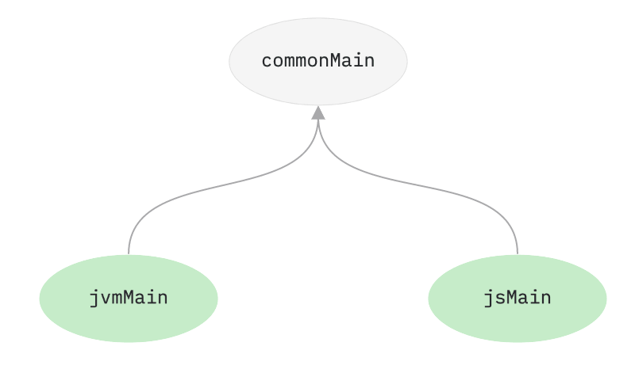

If the source set `jvmMain` depends on a source set `commonMain` then:

- Whenever `jvmMain` is compiled for a certain target, `commonMain` takes part in that compilation as well and is also compiled into the same target binary form, such as JVM class files.
- Sources of `jvmMain` 'see' the declarations of `commonMain`, including internal declarations, and also see the dependencies of `commonMain`, even those specified as `implementation` dependencies.
- `jvmMain` can contain platform-specific implementations for the expected declarations of `commonMain`.
- The resources of `commonMain` are always processed and copied along with the resources of `jvmMain`.
- The language settings of `jvmMain` and `commonMain` should be consistent.

Language settings are checked for consistency in the following ways:

- `jvmMain` should set a `languageVersion` that is greater than or equal to that of `commonMain`.
- `jvmMain` should enable all unstable language features that `commonMain` enables (there's no such requirement for bugfix features).
- `jvmMain` should use all experimental annotations that `commonMain` uses.
- `apiVersion`, bugfix language features, and `progressiveMode` can be set arbitrarily.

© 2010–2020 JetBrains s.r.o. and Kotlin Programming Language contributors  
Licensed under the Apache License, Version 2.0.  
https://kotlinlang.org/docs/reference/mpp-configure-compilations.html